# Reproduced ’A Vector Error Correction Model (VECM) Approach in Explaining the Relationship Between Interest Rate and Inflation Towards Exchange Rate Volatility in Malaysia

Zixia Zhou/Runan Zhang/Adrianna Świerzak

2023-06-03

## 1.Importing the data

To begin, we import the required libraries and define necessary functions. Then, we load our dataset.

```r
library(xts)
library(lmtest)
library(tidyverse)
library(vars)
library(readxl)
library(urca)
```

```r
setwd('/Users/hazelzhou/Desktop/RR')
source("Team-project/functions/testdf.R")
data <- read_excel('Team-project/RR_data.xls')
```

Here is the structure of the data.

```r
data %>% glimpse()
```

```
## Rows: 132
## Columns: 4
## $ Date <dttm> 1999-01-01, 1999-02-01, 1999-03-01, 1999-04-01, 1999-05-01, 1999…
## $ EXC  <dbl> 3.8, 3.8, 3.8, 3.8, 3.8, 3.8, 3.8, 3.8, 3.8, 3.8, 3.8, 3.8, 3.8, …
## $ INF  <dbl> 0.052, 0.038, 0.031, 0.029, 0.029, 0.022, 0.025, 0.023, 0.022, 0.…
## $ IR   <dbl> 0.0572, 0.0558, 0.0539, 0.0399, 0.0375, 0.0375, 0.0375, 0.0375, 0…
```

```r
head(data)
```

```
## # A tibble: 6 × 4
##   Date                  EXC   INF     IR
##   <dttm>              <dbl> <dbl>  <dbl>
## 1 1999-01-01 00:00:00   3.8 0.052 0.0572
## 2 1999-02-01 00:00:00   3.8 0.038 0.0558
## 3 1999-03-01 00:00:00   3.8 0.031 0.0539
## 4 1999-04-01 00:00:00   3.8 0.029 0.0399
## 5 1999-05-01 00:00:00   3.8 0.029 0.0375
## 6 1999-06-01 00:00:00   3.8 0.022 0.0375
```

```r
tail(data)
```

```
## # A tibble: 6 × 4
##   Date                  EXC    INF     IR
##   <dttm>              <dbl>  <dbl>  <dbl>
## 1 2009-07-01 00:00:00  3.54 0.0058 0.0202
## 2 2009-08-01 00:00:00  3.52 0.0058 0.02
## 3 2009-09-01 00:00:00  3.49 0.0058 0.02
## 4 2009-10-01 00:00:00  3.40 0.0058 0.02
## 5 2009-11-01 00:00:00  3.39 0.0058 0.02
## 6 2009-12-01 00:00:00  3.41 0.0058 0.02
```

Next, we proceed to correct the data type of the date variable and convert the `data.frame` into an `xts` object. Then we transform the data into log form as the paper mentioned.

```r
data$Date <- as.Date(data$Date, format = "%Y-%m-%d")
data %>% glimpse()
```

```
## Rows: 132
## Columns: 4
## $ Date <date> 1999-01-01, 1999-02-01, 1999-03-01, 1999-04-01, 1999-05-01, 1999…
## $ EXC  <dbl> 3.8, 3.8, 3.8, 3.8, 3.8, 3.8, 3.8, 3.8, 3.8, 3.8, 3.8, 3.8, 3.8, …
## $ INF  <dbl> 0.052, 0.038, 0.031, 0.029, 0.029, 0.022, 0.025, 0.023, 0.022, 0.…
## $ IR   <dbl> 0.0572, 0.0558, 0.0539, 0.0399, 0.0375, 0.0375, 0.0375, 0.0375, 0…
```

```r
data <- xts(data[, -1], order.by = data$Date)
log.data <- log(data)
```

Let’s create their difference.

```r
log.data$dEXC <- diff.xts(log.data$EXC)
log.data$dINF <- diff.xts(log.data$INF)
log.data$dIR <- diff.xts(log.data$IR)
```

Then, plotting the data.

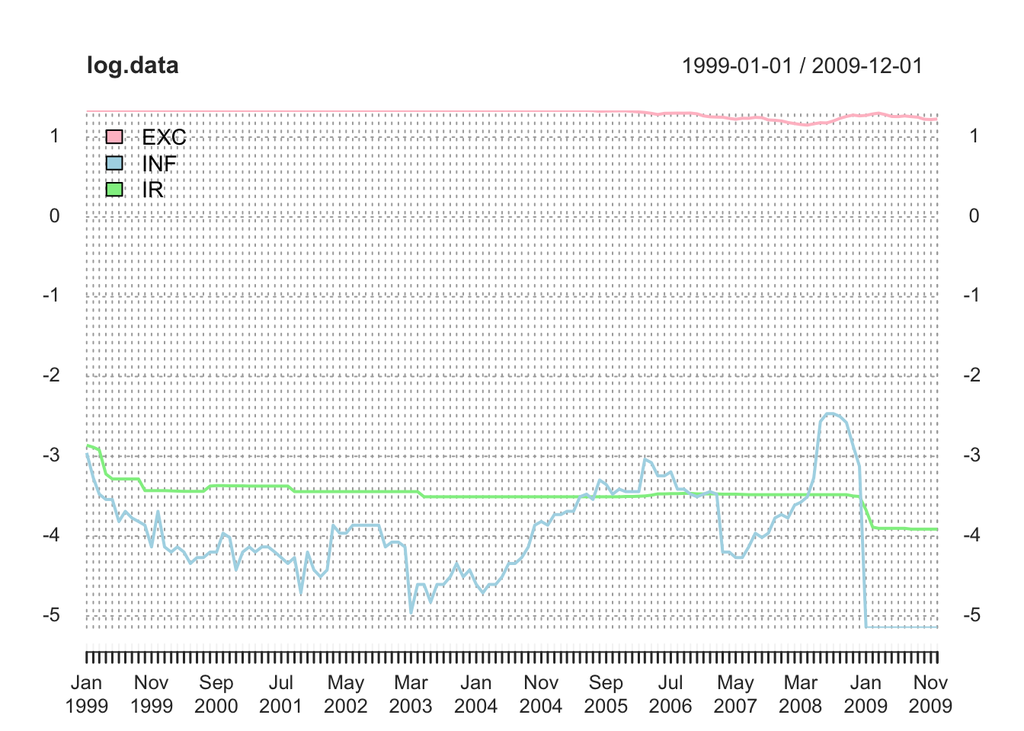

```r
plot(log.data[, c(1:3)],
     col = c("pink", "lightblue","lightgreen"),
     major.ticks = "months",
     grid.ticks.on = "months",
     grid.ticks.lty = 3,
     main = "log.data",
     legend.loc = "topleft")
```

## 2.Stationarity Test

Stationarity refers to the property of a time series where the statistical properties such as mean, variance, and covariance remain constant over time.

We will apply the Augmented Dickey-Fuller (ADF) test and Phillips-Perron (PP) test on the variable `EXC`, `INF`, `IR` and their first differences.

### 2.1.1 ADF test of `EXC`

First, let’s test variable `EXC`.

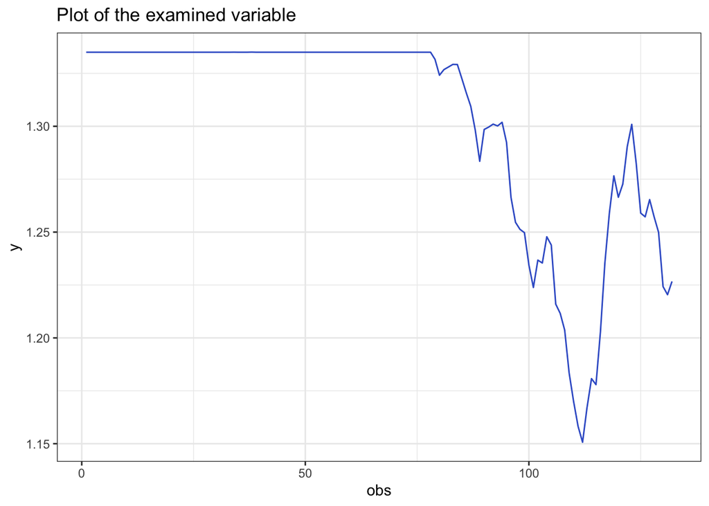

```
##   augmentations        adf     p_adf    bgodfrey            p_bg
## 1             0 -0.4638111 0.8837581 25.77349689 0.0000003839244
## 2             1 -1.3257420 0.5642187  0.45164443 0.5015550736469
## 3             2 -1.0615983 0.6621434  0.07328040 0.7866190642272
## 4             3 -1.3377134 0.5597806  0.01803089 0.8931818310285
```

```r
testdf(variable = log.data$EXC,
       max.augmentations = 3)
```

As we can see, the p-value of Breusch-Godfrey test, which is used to test for autocorrelation in the residuals is very low in first line. In such case, the ADF test is inefficient since the residuals are serial correlation.

**H0 = No Autocorrelation**

**Ha = Autocorrelation**

Let’s interpret the result of first difference.

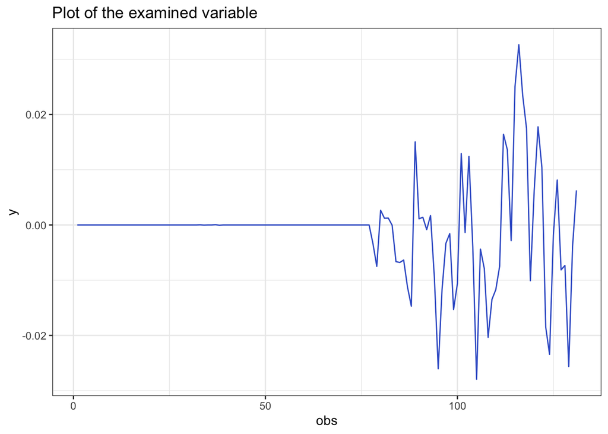

```
##   augmentations       adf p_adf    bgodfrey      p_bg
## 1             0 -7.018000  0.01 0.552533557 0.4572843
## 2             1 -6.866159  0.01 0.080283107 0.7769141
## 3             2 -4.808856  0.01 0.007212422 0.9323202
## 4             3 -4.176373  0.01 0.005685681 0.9398937
```

```r
testdf(variable = log.data$dEXC,
       max.augmentations = 3)
```

In the first row, it shows higher p-value of BG test and and lower p-value of ADF test. It indicates `EXC` is integrated of order 1.

### 2.1.2 PP test of `EXC`

The paper also conducted the Phillips-Perron (PP) which is similar to ADF.

H0: time series is not stationary

Ha: time series is stationary

```r
pp.test.EXC <- ur.pp(log.data$EXC,
                 type = c("Z-tau"),
                 model = c("constant"))
summary(pp.test.EXC)
```

```
##
## ##################################
## # Phillips-Perron Unit Root Test #
## ##################################
##
## Test regression with intercept
##
##
## Call:
## lm(formula = y ~ y.l1)
##
## Residuals:
##       Min        1Q    Median        3Q       Max
## -0.027538  0.000457  0.001045  0.001045  0.032763
##
## Coefficients:
##             Estimate Std. Error t value Pr(>|t|)
## (Intercept) 0.008324   0.019744   0.422    0.674
## y.l1        0.992982   0.015132  65.622   <2e-16 ***
## ---
## Signif. codes:  0 '***' 0.001 '**' 0.01 '*' 0.05 '.' 0.1 ' ' 1
##
## Residual standard error: 0.008491 on 129 degrees of freedom
## Multiple R-squared:  0.9709, Adjusted R-squared:  0.9707
## F-statistic:  4306 on 1 and 129 DF,  p-value: < 2.2e-16
##
##
## Value of test-statistic, type: Z-tau  is: -1.0015
##
##          aux. Z statistics
## Z-tau-mu            0.9709
##
## Critical values for Z statistics:
##                      1pct      5pct     10pct
## critical values -3.480998 -2.883488 -2.578338
```

Test-statistic Z-tau (-1.0015) is higher than the 1% critical value (-3.480998), so we cannot reject the null about non-stationary of `EXC`.

We will also use PP test for the difference of `EXC`.

```r
pp.test.EXC.d <- ur.pp(diff.xts(log.data$EXC),
                   type = c("Z-tau"),
                   model = c("constant"))
summary(pp.test.EXC.d)
```

```
##
## ##################################
## # Phillips-Perron Unit Root Test #
## ##################################
##
## Test regression with intercept
##
##
## Call:
## lm(formula = y ~ y.l1)
##
## Residuals:
##        Min         1Q     Median         3Q        Max
## -0.0257853  0.0004155  0.0004440  0.0004440  0.0267492
##
## Coefficients:
##               Estimate Std. Error t value    Pr(>|t|)
## (Intercept) -0.0004440  0.0006754  -0.657       0.512
## y.l1         0.4415834  0.0795692   5.550 0.000000158 ***
## ---
## Signif. codes:  0 '***' 0.001 '**' 0.01 '*' 0.05 '.' 0.1 ' ' 1
##
## Residual standard error: 0.00766 on 128 degrees of freedom
## Multiple R-squared:  0.1939, Adjusted R-squared:  0.1877
## F-statistic:  30.8 on 1 and 128 DF,  p-value: 0.0000001577
##
##
## Value of test-statistic, type: Z-tau  is: -6.9049
##
##          aux. Z statistics
## Z-tau-mu           -0.6451
##
## Critical values for Z statistics:
##                      1pct      5pct     10pct
## critical values -3.481377 -2.883656 -2.578427
```

Test-statistic Z-tau (-6.9049) is now lower than the 1% critical value (-3.481377), so now we **reject** the null about non-stationary of first differences of `EXC`

By concluding `EXC` ~ I(1)

### 2.2.1 ADF test of `INF`

We are going to repeat the same procedure on variables `INF` and `IR` to see if it is stationary.

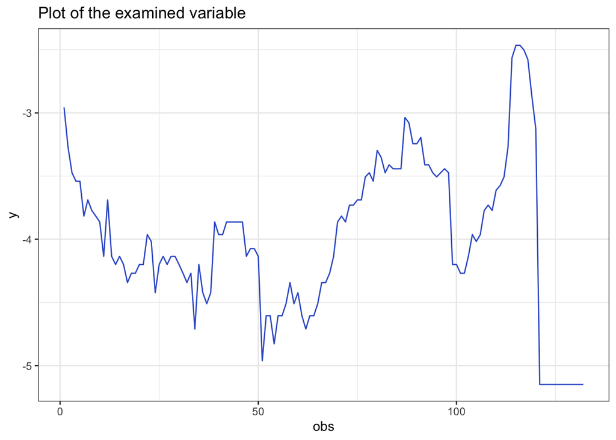

```
##   augmentations       adf      p_adf    bgodfrey      p_bg
## 1             0 -2.403440 0.16468901 0.141562233 0.7067329
## 2             1 -2.270682 0.21390581 0.005378292 0.9415381
## 3             2 -2.422259 0.15771229 0.039314863 0.8428262
## 4             3 -2.806242 0.06317596 0.051402590 0.8206404
```

```r
testdf(variable = log.data$INF,
       max.augmentations = 3)
```

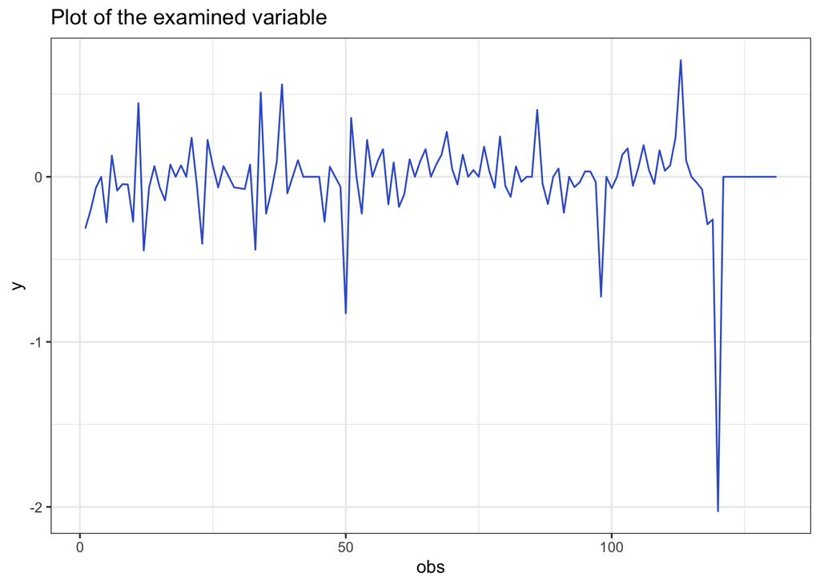

```
##   augmentations        adf p_adf    bgodfrey      p_bg
## 1             0 -11.523831  0.01 0.004087015 0.9490262
## 2             1  -7.584009  0.01 0.006518509 0.9356509
## 3             2  -5.674379  0.01 0.001931325 0.9649468
## 4             3  -4.795138  0.01 0.003970302 0.9497583
```

```r
testdf(variable = log.data$dINF,
       max.augmentations = 3)
```

### 2.2.2 PP test of `INF`

```r
pp.test.INF <- ur.pp(log.data$INF,
                 type = c("Z-tau"),
                 model = c("constant"))
summary(pp.test.INF)
```

```
##
## ##################################
## # Phillips-Perron Unit Root Test #
## ##################################
##
## Test regression with intercept
##
##
## Call:
## lm(formula = y ~ y.l1)
##
## Residuals:
##      Min       1Q   Median       3Q      Max
## -1.93357 -0.07757  0.02743  0.08405  0.78603
##
## Coefficients:
##             Estimate Std. Error t value Pr(>|t|)
## (Intercept) -0.36865    0.14815  -2.488   0.0141 *
## y.l1         0.91168    0.03675  24.808   <2e-16 ***
## ---
## Signif. codes:  0 '***' 0.001 '**' 0.01 '*' 0.05 '.' 0.1 ' ' 1
##
## Residual standard error: 0.2587 on 129 degrees of freedom
## Multiple R-squared:  0.8267, Adjusted R-squared:  0.8254
## F-statistic: 615.4 on 1 and 129 DF,  p-value: < 2.2e-16
##
##
## Value of test-statistic, type: Z-tau  is: -2.7444
##
##          aux. Z statistics
## Z-tau-mu           -2.8111
##
## Critical values for Z statistics:
##                      1pct      5pct     10pct
## critical values -3.480998 -2.883488 -2.578338
```

```r
pp.test.INF.d <- ur.pp(diff.xts(log.data$INF),
                   type = c("Z-tau"),
                   model = c("constant"))
summary(pp.test.INF.d)
```

```
##
## ##################################
## # Phillips-Perron Unit Root Test #
## ##################################
##
## Test regression with intercept
##
##
## Call:
## lm(formula = y ~ y.l1)
##
## Residuals:
##      Min       1Q   Median       3Q      Max
## -2.01513 -0.04898  0.01469  0.08405  0.72409
##
## Coefficients:
##             Estimate Std. Error t value Pr(>|t|)
## (Intercept) -0.01469    0.02321  -0.633    0.528
## y.l1        -0.01347    0.08795  -0.153    0.879
##
## Residual standard error: 0.2641 on 128 degrees of freedom
## Multiple R-squared:  0.0001832,  Adjusted R-squared:  -0.007628
## F-statistic: 0.02345 on 1 and 128 DF,  p-value: 0.8785
##
##
## Value of test-statistic, type: Z-tau  is: -11.546
##
##          aux. Z statistics
## Z-tau-mu           -0.6341
##
## Critical values for Z statistics:
##                      1pct      5pct     10pct
## critical values -3.481377 -2.883656 -2.578427
```

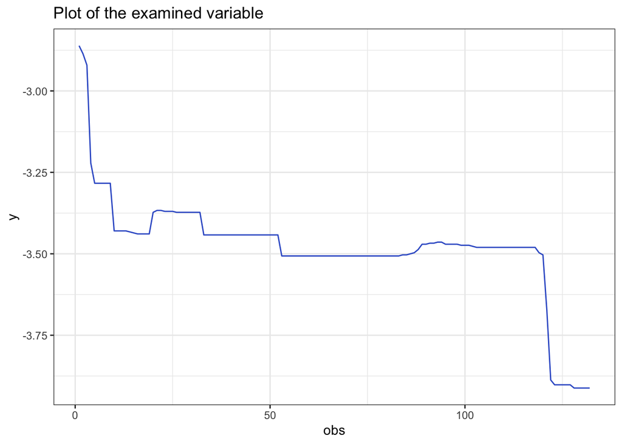

```
##   augmentations        adf      p_adf    bgodfrey         p_bg
## 1             0 -2.8375775 0.05812190 13.01755561 0.0003085844
## 2             1 -3.0208165 0.03795766  0.01838159 0.8921543415
## 3             2 -2.9231031 0.04681279  0.10345872 0.7477178676
## 4             3 -0.1893606 0.93134256  1.14653524 0.2842756218
```

```r
testdf(variable = log.data$IR,
       max.augmentations = 3)
```

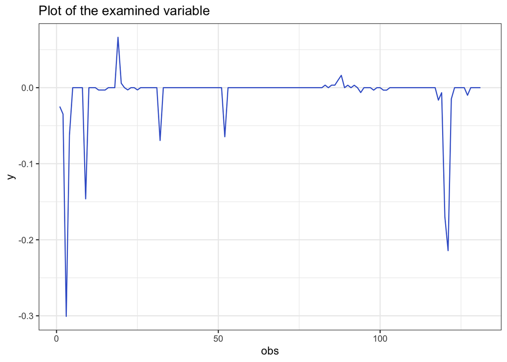

```
##   augmentations       adf p_adf    bgodfrey      p_bg
## 1             0 -8.144615  0.01 0.045861049 0.8304286
## 2             1 -7.022562  0.01 0.149967820 0.6985661
## 3             2 -8.523969  0.01 1.086231876 0.2973076
## 4             3 -6.270570  0.01 0.002551711 0.9597124
```

```r
testdf(variable = log.data$dIR,
       max.augmentations = 3)
```

### 2.3.2 PP test of `IR`

```r
pp.test.IR <- ur.pp(log.data$IR,
                 type = c("Z-tau"),
                 model = c("constant"))
summary(pp.test.IR)
```

```
##
## ##################################
## # Phillips-Perron Unit Root Test #
## ##################################
##
## Test regression with intercept
##
##
## Call:
## lm(formula = y ~ y.l1)
##
## Residuals:
##       Min        1Q    Median        3Q       Max
## -0.260051  0.006288  0.007834  0.010079  0.076551
##
## Coefficients:
##             Estimate Std. Error t value Pr(>|t|)
## (Intercept) -0.21225    0.07205  -2.946  0.00382 **
## y.l1         0.94126    0.02070  45.473  < 2e-16 ***
## ---
## Signif. codes:  0 '***' 0.001 '**' 0.01 '*' 0.05 '.' 0.1 ' ' 1
##
## Residual standard error: 0.03805 on 129 degrees of freedom
## Multiple R-squared:  0.9413, Adjusted R-squared:  0.9408
## F-statistic:  2068 on 1 and 129 DF,  p-value: < 2.2e-16
##
##
## Value of test-statistic, type: Z-tau  is: -2.9002
##
##          aux. Z statistics
## Z-tau-mu           -2.9853
##
## Critical values for Z statistics:
##                      1pct      5pct     10pct
## critical values -3.480998 -2.883488 -2.578338
```

```r
pp.test.IR.d <- ur.pp(diff.xts(log.data$IR),
                   type = c("Z-tau"),
                   model = c("constant"))
summary(pp.test.IR.d)
```

```
##
## ##################################
## # Phillips-Perron Unit Root Test #
## ##################################
##
## Test regression with intercept
##
##
## Call:
## lm(formula = y ~ y.l1)
##
## Residuals:
##       Min        1Q    Median        3Q       Max
## -0.284419  0.005323  0.005323  0.005323  0.071613
##
## Coefficients:
##              Estimate Std. Error t value Pr(>|t|)
## (Intercept) -0.005323   0.003341  -1.594 0.113509
## y.l1         0.317865   0.083753   3.795 0.000227 ***
## ---
## Signif. codes:  0 '***' 0.001 '**' 0.01 '*' 0.05 '.' 0.1 ' ' 1
##
## Residual standard error: 0.0373 on 128 degrees of freedom
## Multiple R-squared:  0.1011, Adjusted R-squared:  0.09413
## F-statistic:  14.4 on 1 and 128 DF,  p-value: 0.0002265
##
##
## Value of test-statistic, type: Z-tau  is: -8.0244
##
##          aux. Z statistics
## Z-tau-mu           -1.5687
##
## Critical values for Z statistics:
##                      1pct      5pct     10pct
## critical values -3.481377 -2.883656 -2.578427
```

It is evident that the variable `IR` exhibits stationary in both ADF test and PP test of its levels at significant level of 5%.

## 3.Determination of Lags and Cointegration Test

### 3.1 Determination of Lags

Determining the appropriate number of lags for VECM can be important for accurate analysis. Here we will use the function VARselect.

```r
log.data.vecm <- log.data[,c(1:3)]
VARselect(log.data.vecm,
          lag.max = 5)
```

```
## $selection
## AIC(n)  HQ(n)  SC(n) FPE(n)
##      5      2      2      5
##
## $criteria
##                          1                   2                   3
## AIC(n) -19.410358351209133 -19.833579613412216 -19.826960942912237
## HQ(n)  -19.301171684011763 -19.642502945816819 -19.553994274918814
## SC(n)  -19.141616264299660 -19.363280961320637 -19.155105725638553
## FPE(n)   0.000000003717197   0.000000002435183   0.000000002452934
##                          4                   5
## AIC(n) -19.817142200539703 -19.850694727647305
## HQ(n)  -19.462285532148254 -19.413948058857830
## SC(n)  -18.943730418083913 -18.775726380009409
## FPE(n)   0.000000002480059   0.000000002402738
```

As we could see the lower the value of criteria, the better model. We choose the lag 2.

### 3.2 Cointegration Test

The Johansen test is a statistical procedure utilized to assess whether a group of time series variables exhibit cointegration. Cointegration suggests the existence of a long-term equilibrium relationship among the variables, indicating that they move together in the long run despite short-term fluctuations. It is a foundation of the VECM. Here we will conduct **Trace test**.

```r
johan.test.trace <-
  ca.jo(log.data.vecm,
        ecdet = "const",
        type = "trace",
        K = 2)
summary(johan.test.trace)
```

```
##
## ######################
## # Johansen-Procedure #
## ######################
##
## Test type: trace statistic , without linear trend and constant in cointegration
##
## Eigenvalues (lambda):
## [1] 1.293398e-01 7.780369e-02 3.035640e-02 3.490128e-18
##
## Values of teststatistic and critical values of test:
##
##           test 10pct  5pct  1pct
## r <= 2 |  4.01  7.52  9.24 12.97
## r <= 1 | 14.54 17.85 19.96 24.60
## r = 0  | 32.54 32.00 34.91 41.07
##
## Eigenvectors, normalised to first column:
## (These are the cointegration relations)
##
##               EXC.l2     INF.l2        IR.l2    constant
## EXC.l2    1.00000000  1.0000000  1.000000000  1.00000000
## INF.l2    0.08280387  0.3841599  0.009831794 -0.02018869
## IR.l2    -0.56275953 -0.1448445 -0.072247475  0.25090909
## constant -2.95584380 -0.2720077 -1.470597027 -0.56980152
##
## Weights W:
## (This is the loading matrix)
##
##             EXC.l2       INF.l2       IR.l2      constant
## EXC.d -0.008068715  0.005097857 -0.01776466  6.836756e-16
## INF.d -0.407817910 -0.312115657 -0.27690082  2.145580e-14
## IR.d   0.152746290 -0.022284524 -0.03345994 -7.129880e-15
```

As the result, we could **Reject** the null hypothesis r=0 at significant level of 10% and cannot reject the null hypothesis r <= 1 since the test statistic is lower than the critical value. Given that the rank of the Johansen test results is equal to 1, which is greater than zero but less than the number of variables, it indicates that the series are cointegrated. Therefore, we can proceed with estimating the VECM.

## 4. Vector Error Correction Model

```r
model <- lm(EXC ~ INF + IR, data = log.data)
summary(model)
```

```
##
## Call:
## lm(formula = EXC ~ INF + IR, data = log.data)
##
## Residuals:
##      Min       1Q   Median       3Q      Max
## -0.13378 -0.01063  0.01261  0.02341  0.05653
##
## Coefficients:
##              Estimate Std. Error t value       Pr(>|t|)
## (Intercept)  1.774524   0.079577  22.299        < 2e-16 ***
## INF         -0.038686   0.006851  -5.647 0.000000099296 ***
## IR           0.179788   0.025883   6.946 0.000000000166 ***
## ---
## Signif. codes:  0 '***' 0.001 '**' 0.01 '*' 0.05 '.' 0.1 ' ' 1
##
## Residual standard error: 0.04186 on 129 degrees of freedom
## Multiple R-squared:  0.2953, Adjusted R-squared:  0.2843
## F-statistic: 27.02 on 2 and 129 DF,  p-value: 0.0000000001577
```

As the results show, both of the dependent variables are significant since the p-values are lower than significant level 1%. The variable `INF` has negative relationship with `EXC` and `IR` has positive relationship with `EXC`. It states the same finding in the paper.
$$EXC
= 0.179788IR - 0.038686INF$$

## 5. Granger Causality test

The Granger causality test is a statistical test used to determine whether one time series variable can predict another time series variable.

```r
grangertest(EXC ~ IR,
            data = log.data,
            order = 2)
```

```
## Granger causality test
##
## Model 1: EXC ~ Lags(EXC, 1:2) + Lags(IR, 1:2)
## Model 2: EXC ~ Lags(EXC, 1:2)
##   Res.Df Df      F Pr(>F)
## 1    125
## 2    127 -2 1.7149 0.1842
```

```r
grangertest(IR ~ EXC,
            data = log.data,
            order = 2)
```

```
## Granger causality test
##
## Model 1: IR ~ Lags(IR, 1:2) + Lags(EXC, 1:2)
## Model 2: IR ~ Lags(IR, 1:2)
##   Res.Df Df      F Pr(>F)
## 1    125
## 2    127 -2 0.5953 0.5529
```

```r
grangertest(EXC ~ INF,
            data = log.data,
            order = 2)
```

```
## Granger causality test
##
## Model 1: EXC ~ Lags(EXC, 1:2) + Lags(INF, 1:2)
## Model 2: EXC ~ Lags(EXC, 1:2)
##   Res.Df Df      F Pr(>F)
## 1    125
## 2    127 -2 1.8985 0.1541
```

```r
grangertest(INF ~ EXC,
            data = log.data,
            order = 5)
```

```
## Granger causality test
##
## Model 1: INF ~ Lags(INF, 1:5) + Lags(EXC, 1:5)
## Model 2: INF ~ Lags(INF, 1:5)
##   Res.Df Df      F   Pr(>F)
## 1    116
## 2    121 -5 3.8527 0.002887 **
## ---
## Signif. codes:  0 '***' 0.001 '**' 0.01 '*' 0.05 '.' 0.1 ' ' 1
```

```r
grangertest(IR ~ INF,
            data = log.data,
            order = 2)
```

```
## Granger causality test
##
## Model 1: IR ~ Lags(IR, 1:2) + Lags(INF, 1:2)
## Model 2: IR ~ Lags(IR, 1:2)
##   Res.Df Df      F    Pr(>F)
## 1    125
## 2    127 -2 8.6497 0.0003032 ***
## ---
## Signif. codes:  0 '***' 0.001 '**' 0.01 '*' 0.05 '.' 0.1 ' ' 1
```

```r
grangertest(INF ~ IR,
            data = log.data,
            order = 2)
```

```
## Granger causality test
##
## Model 1: INF ~ Lags(INF, 1:2) + Lags(IR, 1:2)
## Model 2: INF ~ Lags(INF, 1:2)
##   Res.Df Df      F Pr(>F)
## 1    125
## 2    127 -2 0.8711  0.421
```

[output not shown]

## 6. Impulse Response Function

Now we reparametrize the VECM into VAR in order to calculate and plot Impulse Response Function.

```r
log.data.vecm.asVAR <-vec2var(johan.test.trace, r = 1)
log.data.vecm.asVAR
```

```
##
## Coefficient matrix of lagged endogenous variables:
##
## A1:
##         EXC.l1       INF.l1         IR.l1
## EXC 1.44297726 -0.002759284 -0.0001051308
## INF 1.51483279  0.941233273  1.0194831124
## IR  0.08991563  0.056814421  1.1457801247
##
##
## A2:
##          EXC.l2       INF.l2        IR.l2
## EXC -0.45104597  0.002091163  0.004645877
## INF -1.92265070  0.024997824 -0.789979698
## IR   0.06283066 -0.044166436 -0.231739555
##
##
## Coefficient matrix of deterministic regressor(s).
##
##        constant
## EXC  0.02384986
## INF  1.20544604
## IR  -0.45149417
```

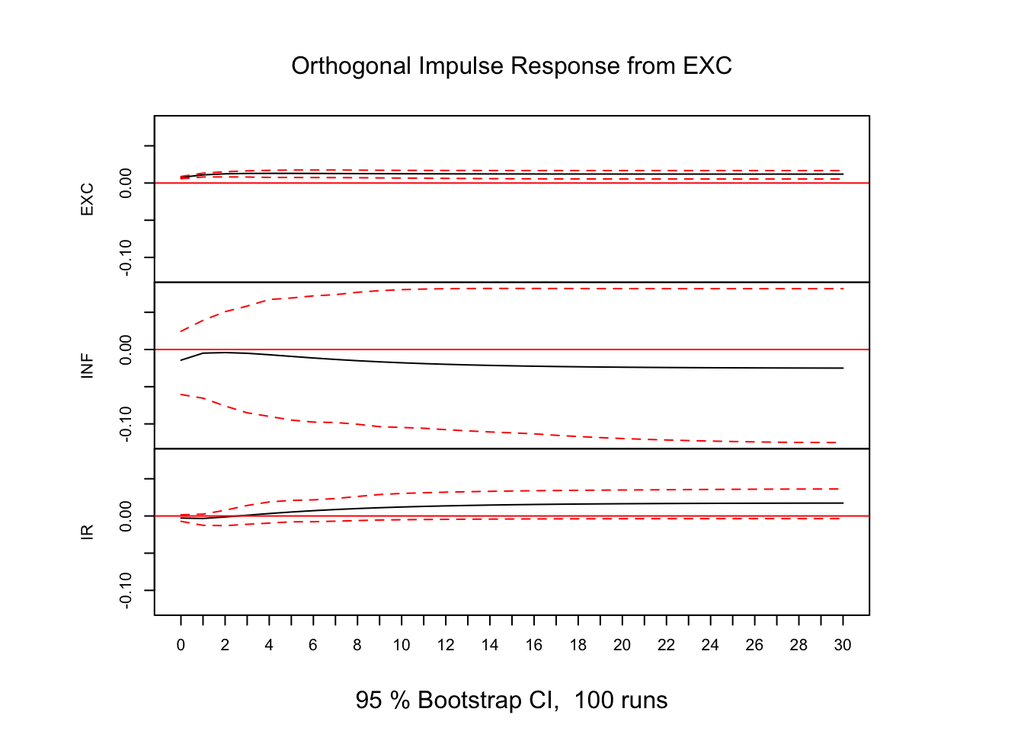

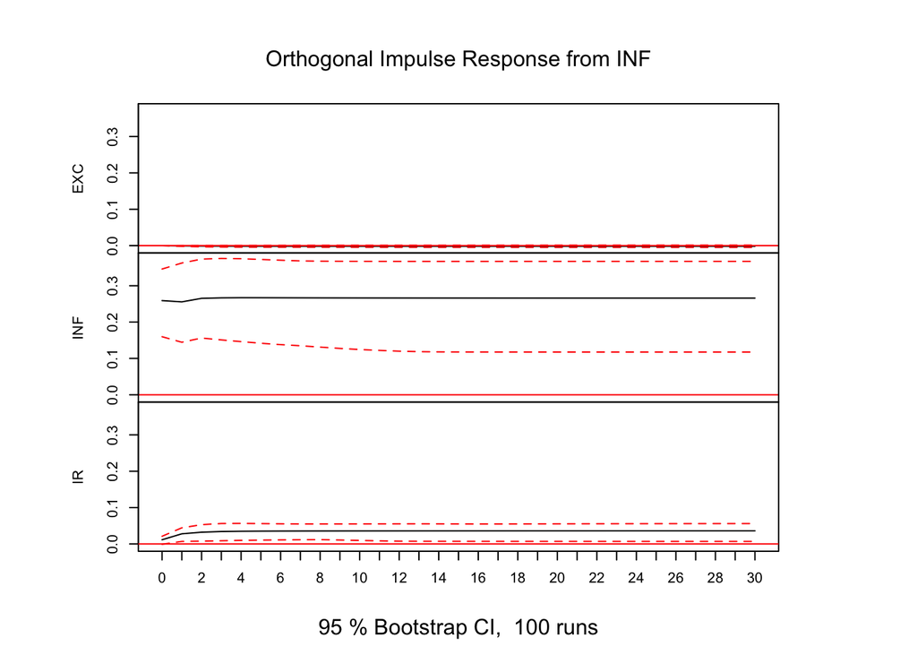

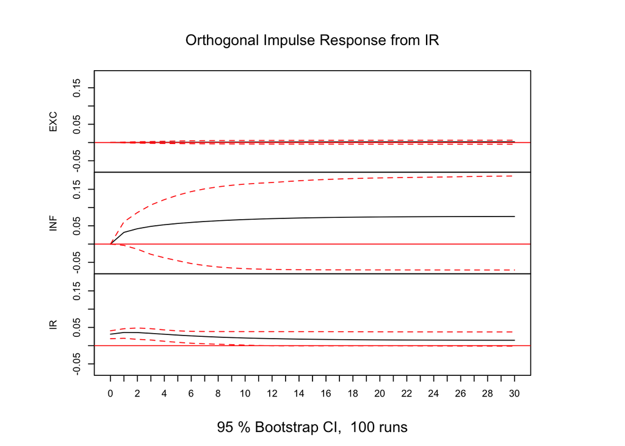

```r
plot(irf(log.data.vecm.asVAR, n.ahead = 30))
```

Impulse Response Function can be used to show how the system responds over time to shocks or sudden changes in other factors. Here, we could see from the plot 1 and 2 that `EXC` is relatively stable for the adding shocks from `INF`, also, `INF` is neutral for additinal `EXC` shocks – i.e., irresponsive. From plot 2, `IR` goes up at the initial and towards stability response for `INF` shocks.